# Examining Time-Averaged Annual Uncertainty

Sebastian T. Rowland

8/23/2021

## Set up data

We will pull in the already-preapred data, for which we joined BNE estimates and potential explanatory variables with nearest-neighbors.

```
## [1] "Distribution of Predictive Uncertainty"
```

```
##     mean   sd  min   Q1 median   Q3  max
## 25% 0.77 0.33 0.26 0.52   0.69 0.96 2.38
```

## Crude Correlations

Let’s look at the overall correlation

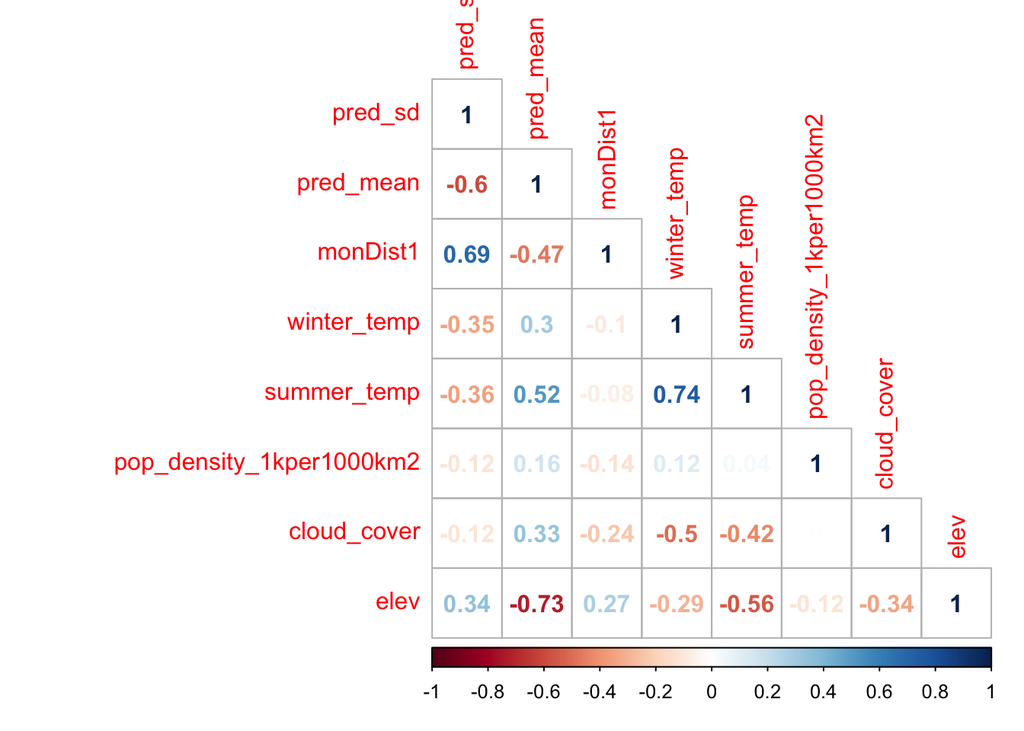

```r
dta.dist <- dta %>%
  dplyr::select(pred_sd, pred_mean, monDist1,winter_temp, summer_temp, pop_density_1kper1000km2, cloud_cover, elev )
dta.dist.cor <- cor(dta.dist)

corrplot(dta.dist.cor, method = 'number', type = 'lower')
```

Let’s next look at the correlation between distance to nearest monitor and predictive uncertainty. We see that actually the correlation increases as we consider further monitors, though the correlation plateau’s around the fourth-nearest monitor.

The key insight is that the the distance to the fourth-nearest monitor actually tells us a lot about the nearest monitor and second and third-nearest monitors. The distance to the fourth-nearest monitor tells us the maximum possible distance of the 3 more-proximate monitors. For exmaple, if the distance to the fourth-nearest monitor is 10 km, then the nearest monitor must also be within 10 km of the point. Low distance to fourth-nearest monitor indicates high monitor density. These distances are pretty correlated, though not completely.

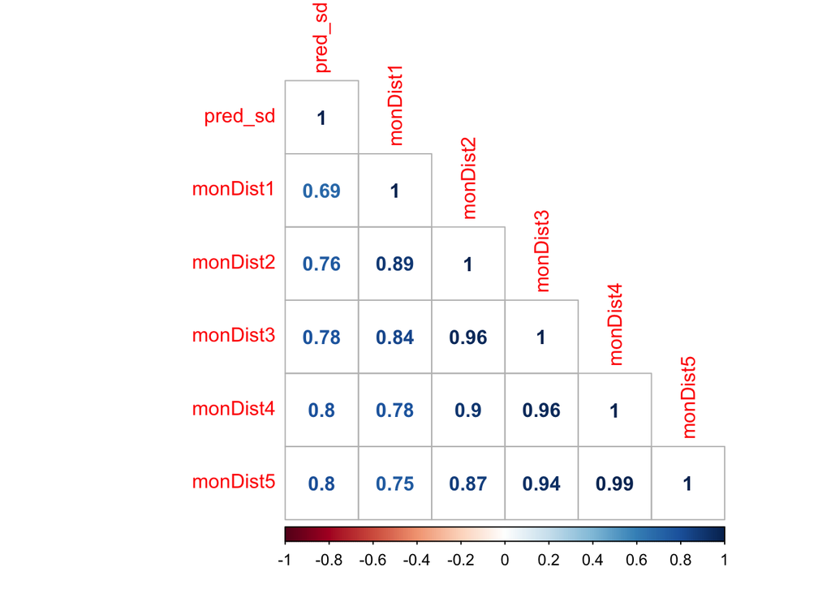

```r
dta.dist <- dta %>%
  dplyr::select(pred_sd, monDist1, monDist2, monDist3, monDist4, monDist5)
dta.dist.cor <- cor(dta.dist)

corrplot(dta.dist.cor, method = 'number', type = 'lower')
```

Next let’s fit a model with just one monitor-proximity metric, distance to nearest monitor, and then check the association.

```r
mod.allPsp <- gam(pred_sd ~ s(pred_mean) + s(monDist1)  +  s(winter_temp) + s(summer_temp) + s(pop_density_1kper1000km2) + s(cloud_cover) + s(elev) , data = dta)
summary(mod.allPsp)$s.table[,1]
```

```
##                s(pred_mean)                 s(monDist1)
##                    8.415391                    7.903246
##              s(winter_temp)              s(summer_temp)
##                    8.801128                    8.361118
## s(pop_density_1kper1000km2)              s(cloud_cover)
##                    1.000000                    8.892225
##                     s(elev)
##                    7.857960
```

## Create Non-Spatial Model

We see that population density has an estimated degree of freedom of 1, so we can model it as a linear term. Now let’s create that model, and take a look at the relationship between nearest-monitor and predictive uncertainty.

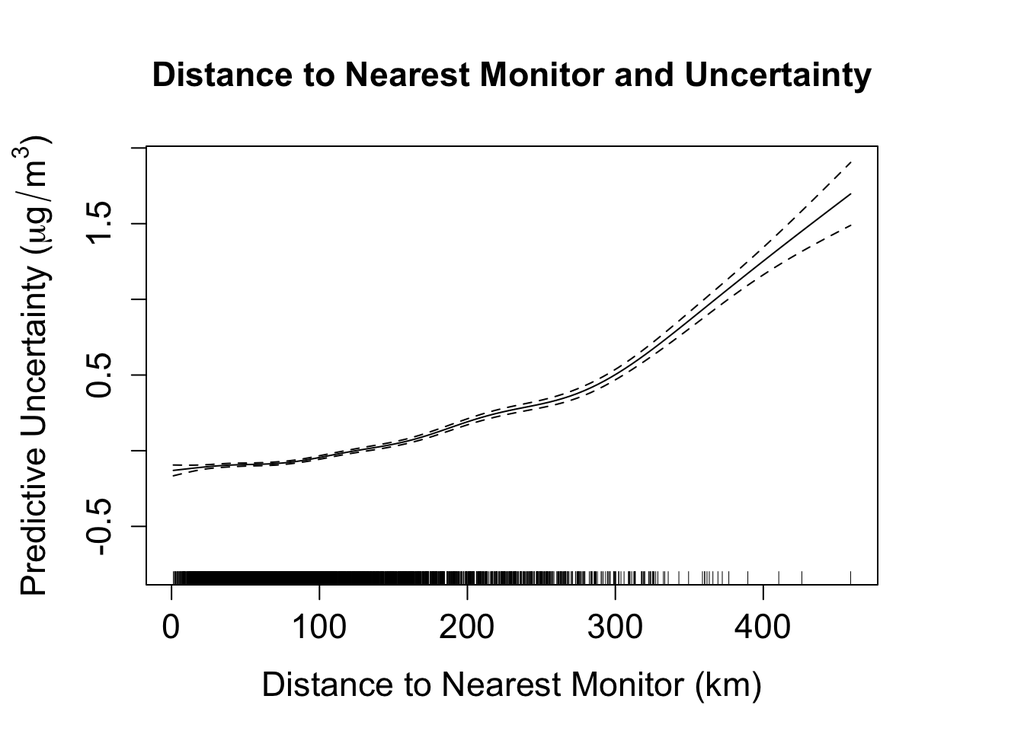

```r
mod.nonsp <- gam(pred_sd ~ s(pred_mean) + s(monDist1) +  s(winter_temp) + s(summer_temp) + pop_density_1kper1000km2 + s(cloud_cover) + s(elev) , data = dta)
par(mar = c(5, 5, 5,5))
plot(mod.nonsp, rug = TRUE, select = 2,
     xlab = 'Distance to Nearest Monitor (km)',
     ylab = expression('Predictive Uncertainty ('*mu*g/m^3*')'),
     main = 'Distance to Nearest Monitor and Uncertainty',
     cex.lab = 1.4, cex.axis = 1.4, cex.main = 1.4)
```

```r
# also report the deviance explained.
mod.nonsp.noMonDist <- gam(pred_sd ~ s(pred_mean) + s(winter_temp) + s(summer_temp) + pop_density_1kper1000km2 + s(cloud_cover) + s(elev), data = dta,
                           sp = c(mod.nonsp$sp[1], mod.nonsp$sp[3:6]))

pd <- calculatePropDevianceExplained(modPartial = mod.nonsp.noMonDist,
                               modFull = mod.nonsp)
print(paste0('Proportion Deviance explained by distance to nearest monitor: ',
             pd))
```

```
## [1] "Proportion Deviance explained by distance to nearest monitor: 0.425867812490115"
```